# Blog Posts

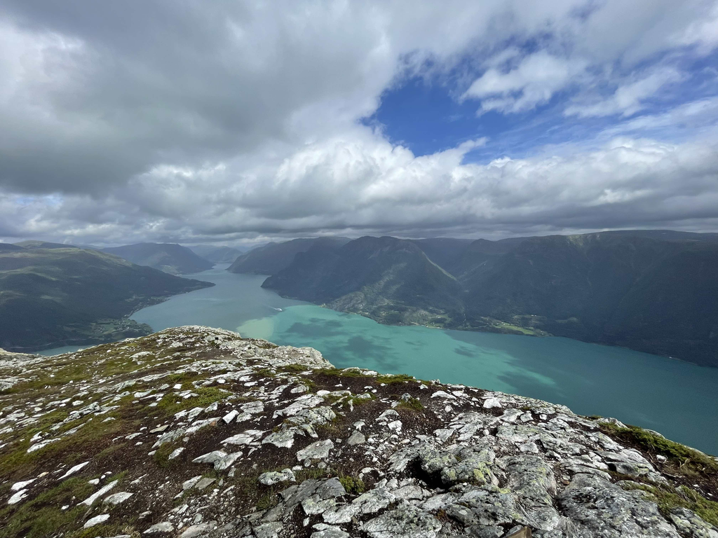

### Teaching R and Reproducibility in Norway

R

Reproducibility

Teaching

Data Science

AI/ML

Aug 20, 2025

[figure not shown]

### Introduction to GitHub Actions for Analysts & Engineers

Back in February, I presented a live demonstration on GitHub Actions for the NCI Bioinformatics Training and Education Program Coding Club.

Feb 19, 2025

### Name change

⚭

Dec 16, 2024

[figure not shown]

### Just enough Python for Snakemake

R

Python

Snakemake

code club

A tutorial for R users who want to write advanced Snakemake workflows

Nov 22, 2022

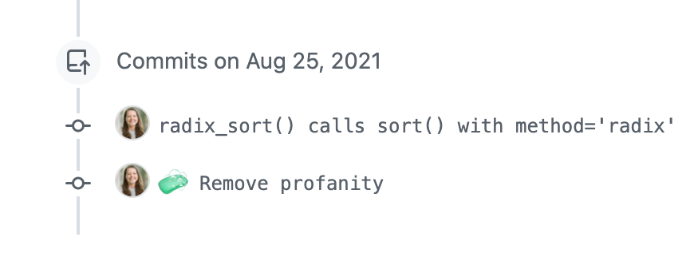

### Base R’s sort() order changes with locale

Software Development

R

R Packages

And that can cause frustrating test failures in devtools::check()!

Aug 26, 2021

### Teach yourself to Code

R

Python

Lab work paused due to covid? You could learn how to code!

Mar 20, 2020

Kelly L. Sovacool, Zena M. Lapp

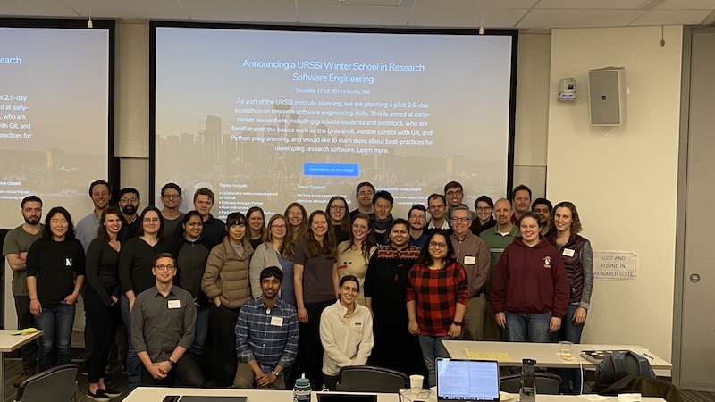

### URSSI Winter School

Research Software Engineering

Open Source Software

Reproducibility

Software Development

Python

git

My notes from the URSSI Winter School

Dec 19, 2019

### Bioinformatics Resources

Bioinformatics

Software Development

Data Science

Reproducibility

Python

R

git

Resources for Bioinformatics Software Development & Data Analysis

May 15, 2019